# Part II - (Ford GoBike Dataset Visualization)

## by (Ugochukwu Ayomide Onyebuchi)

## Investigation Overview

This notebook investigates the behaviour of the various genders and user types in the bike sharing business in order to recognize patterns and also trip duration behaviours

## Dataset Overview

This data set includes information about individual rides made in a bike-sharing system covering the greater San Francisco Bay area. This data covers the period of February in 2019.

## (Distribution of Gender)

Gender refers to the gender of the bike-share users, we have Male, Female and Other Majority of the bike sharers are male and it is interesting to note that other type of gender was captured in 'Other'

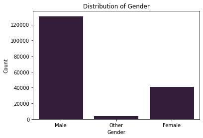

## (Distribution of User Type)

A bike-share user could be of two types: Customer and Subscriber. A large portion of the users are Subscribers.

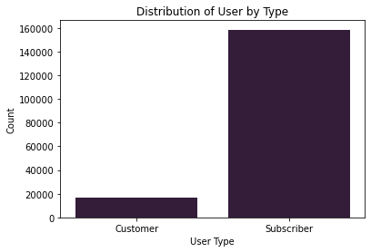

## (Trips by week day)

Thursday seems to be a very popular day for taking a trip, followed by Tuesdays. On weekends the amount of trips are lower in comparison to weekdays

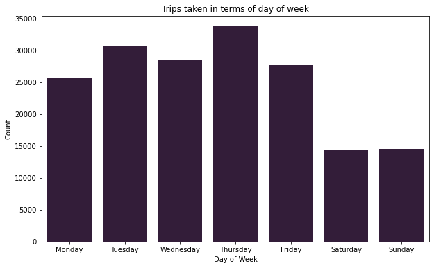

## (Trips by hour of the day)

Well, most trips seem to happen around the 17th hour(5:00pm) and closely following 8th hour(8:00am), coincidentally that's work hour starting and ending hour 🤔

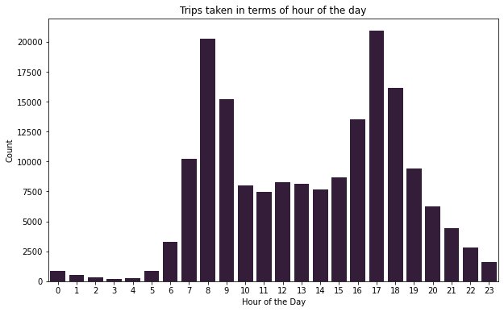

## (Distribution of Duration)

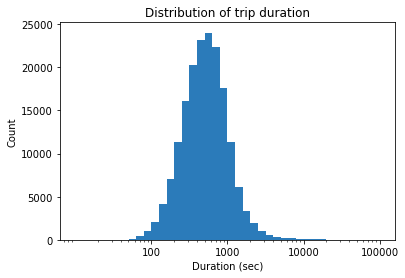

## (User Type vs Gender)

Here we look at the various user types and how they spread across gender, Females tend to be customers than subscribers, Males tend to be subscribers than customers, The other group of gender also tend to be customers than subscribers.

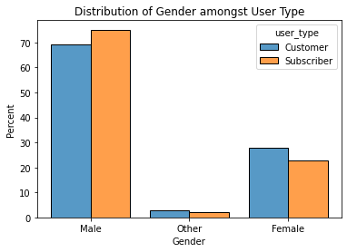

## (User Type vs Duration)

Here we inspect how much each user type spends on a trip on average, we see that Customers seem to spend more time during a trip than subscribers do.

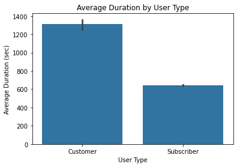

## (User Type vs Gender vs Duration)

- On average female customers spend around 1450 seconds on a trip, male customers spend 1250 seconds on a trip, while the 'other' gender spends the highest with about 1600 seconds on a trip
- Male subscribers on average spend a little above 600 seconds, while female subscribers spend about 700 seconds on a trip, the 'other' gender spends about 900 seconds.

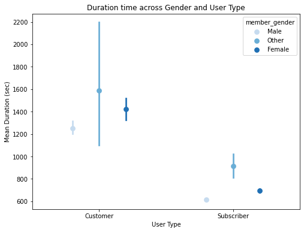